# NOAA Storm Data Analysis

## *Storm event types and damages*

### Summary

This analysis addresses the following questions:

1. Across the United States, which types of events (as indicated in the `EVTYPE` variable) are most harmful with respect to population health?
2. Across the United States, which types of events have the greatest economic consequences?

The events in the database start in the year 1950 and end in November 2011. In the earlier years of the database there are generally fewer events recorded, most likely due to a lack of good records. More recent years should be considered more complete.

### Data Processing

**STEP 1:** Read and cache the data

```r
data <- read.csv("repdata_data_StormData.csv.bz2")
```

**STEP 2:** Subset Data A summary of the NOAA Storm Database tracks a myriad of weather phenomen and their impact on our civilization. For the purposes of this analysis, we will only consider the following variables:

```r
columns <- c("EVTYPE", "FATALITIES", "INJURIES", "PROPDMG", "PROPDMGEXP", "CROPDMG", "CROPDMGEXP")
subdata <- data[columns]
summary(subdata)
```

```
##                EVTYPE         FATALITIES     INJURIES         PROPDMG
##  HAIL             :288661   Min.   :  0   Min.   :   0.0   Min.   :   0
##  TSTM WIND        :219940   1st Qu.:  0   1st Qu.:   0.0   1st Qu.:   0
##  THUNDERSTORM WIND: 82563   Median :  0   Median :   0.0   Median :   0
##  TORNADO          : 60652   Mean   :  0   Mean   :   0.2   Mean   :  12
##  FLASH FLOOD      : 54277   3rd Qu.:  0   3rd Qu.:   0.0   3rd Qu.:   0
##  FLOOD            : 25326   Max.   :583   Max.   :1700.0   Max.   :5000
##  (Other)          :170878
##    PROPDMGEXP        CROPDMG        CROPDMGEXP
##         :465934   Min.   :  0.0          :618413
##  K      :424665   1st Qu.:  0.0   K      :281832
##  M      : 11330   Median :  0.0   M      :  1994
##  0      :   216   Mean   :  1.5   k      :    21
##  B      :    40   3rd Qu.:  0.0   0      :    19
##  5      :    28   Max.   :990.0   B      :     9
##  (Other):    84                   (Other):     9
```

**STEP 3:** Verify Data Types As we can see below, the data types are ok for use in this analysis.

```r
subdata_types <- vector()
for(i in 1:ncol(subdata)){
    subdata_types[i] <- class(subdata[,i])
}
vars <- names(subdata)
subdata_types <- data.frame(vars, subdata_types)
names(subdata_types) <- c("variable", "data_type")
subdata_types
```

```
##     variable data_type
## 1     EVTYPE    factor
## 2 FATALITIES   numeric
## 3   INJURIES   numeric
## 4    PROPDMG   numeric
## 5 PROPDMGEXP    factor
## 6    CROPDMG   numeric
## 7 CROPDMGEXP    factor
```

**STEP 4:** Process Data Per the data logging instructions, all monetary values are store in 2 values: *PROPDMG*/*PROPDMGEXP* and C*CROPDMG*/*CROPDMGEXP*. To obtain the real monetary value as a numeric, we must

**4.1)** Convert the value in *DMGEXP* to numeric. The codebook only describes *B* (billions), *M* (millions), and *K* (thousands). However the data shows the following values:

```r
unique(subdata$PROPDMGEXP)
```

```
##  [1] K M   B m + 0 5 6 ? 4 2 3 h 7 H - 1 8
## Levels:  - ? + 0 1 2 3 4 5 6 7 8 B h H K m M
```

The values *+*,*-*, *“”*, and *?* are not defined and will be interpreted as 1 to preserve any raw value shown in the corresponding *PROPDMG* column. The numeric values are also not defined in the code book and will be defined as *1e+01*, *1e+02*, etc…

```r
subdata$PROPDMGEXP <- as.vector(subdata$PROPDMGEXP)
subdata$PROPDMGEXP[subdata$PROPDMGEXP == "H"] <- 100
subdata$PROPDMGEXP[subdata$PROPDMGEXP == "h"] <- 100
subdata$PROPDMGEXP[subdata$PROPDMGEXP == "K"] <- 1000
subdata$PROPDMGEXP[subdata$PROPDMGEXP == "m"] <- 1e+06
subdata$PROPDMGEXP[subdata$PROPDMGEXP == "M"] <- 1e+06
subdata$PROPDMGEXP[subdata$PROPDMGEXP == "B"] <- 1e+09
subdata$PROPDMGEXP[subdata$PROPDMGEXP == "1"] <- 1e+01
subdata$PROPDMGEXP[subdata$PROPDMGEXP == "2"] <- 1e+02
subdata$PROPDMGEXP[subdata$PROPDMGEXP == "3"] <- 1e+03
subdata$PROPDMGEXP[subdata$PROPDMGEXP == "4"] <- 1e+04
subdata$PROPDMGEXP[subdata$PROPDMGEXP == "5"] <- 1e+05
subdata$PROPDMGEXP[subdata$PROPDMGEXP == "6"] <- 1e+06
subdata$PROPDMGEXP[subdata$PROPDMGEXP == "7"] <- 1e+07
subdata$PROPDMGEXP[subdata$PROPDMGEXP == "8"] <- 1e+08
subdata$PROPDMGEXP[subdata$PROPDMGEXP == "+"] <- 1
subdata$PROPDMGEXP[subdata$PROPDMGEXP == "-"] <- 1
subdata$PROPDMGEXP[subdata$PROPDMGEXP == "?"] <- 1
subdata$PROPDMGEXP[subdata$PROPDMGEXP == "0"] <- 1
subdata$PROPDMGEXP[subdata$PROPDMGEXP == ""] <- 1

subdata$CROPDMGEXP <- as.vector(subdata$CROPDMGEXP)
subdata$CROPDMGEXP[subdata$CROPDMGEXP == "H"] <- 100
subdata$CROPDMGEXP[subdata$CROPDMGEXP == "h"] <- 100
subdata$CROPDMGEXP[subdata$CROPDMGEXP == "K"] <- 1000
subdata$CROPDMGEXP[subdata$CROPDMGEXP == "m"] <- 1e+06
subdata$CROPDMGEXP[subdata$CROPDMGEXP == "M"] <- 1e+06
subdata$CROPDMGEXP[subdata$CROPDMGEXP == "B"] <- 1e+09
subdata$CROPDMGEXP[subdata$CROPDMGEXP == "1"] <- 1e+01
subdata$CROPDMGEXP[subdata$CROPDMGEXP == "2"] <- 1e+02
subdata$CROPDMGEXP[subdata$CROPDMGEXP == "3"] <- 1e+03
subdata$CROPDMGEXP[subdata$CROPDMGEXP == "4"] <- 1e+04
subdata$CROPDMGEXP[subdata$CROPDMGEXP == "5"] <- 1e+05
subdata$CROPDMGEXP[subdata$CROPDMGEXP == "6"] <- 1e+06
subdata$CROPDMGEXP[subdata$CROPDMGEXP == "7"] <- 1e+07
subdata$CROPDMGEXP[subdata$CROPDMGEXP == "8"] <- 1e+08
subdata$CROPDMGEXP[subdata$CROPDMGEXP == "+"] <- 1
subdata$CROPDMGEXP[subdata$CROPDMGEXP == "-"] <- 1
subdata$CROPDMGEXP[subdata$CROPDMGEXP == "?"] <- 1
subdata$CROPDMGEXP[subdata$CROPDMGEXP == "0"] <- 1
subdata$CROPDMGEXP[subdata$CROPDMGEXP == ""] <- 1

subdata$CROPDMGEXP <- as.numeric(subdata$CROPDMGEXP)
subdata$PROPDMGEXP <- as.numeric(subdata$PROPDMGEXP)
```

**4.2** Multiply the *DMG* by the value described in *DMGEXP*.

```r
subdata$PROPDMG <- subdata$PROPDMG * subdata$PROPDMGEXP
head(subdata[subdata$PROPDMG > 0,])
```

```
##    EVTYPE FATALITIES INJURIES PROPDMG PROPDMGEXP CROPDMG CROPDMGEXP
## 1 TORNADO          0       15   25000       1000       0          1
## 2 TORNADO          0        0    2500       1000       0          1
## 3 TORNADO          0        2   25000       1000       0          1
## 4 TORNADO          0        2    2500       1000       0          1
## 5 TORNADO          0        2    2500       1000       0          1
## 6 TORNADO          0        6    2500       1000       0          1
```

```r
head(subdata[subdata$CROPDMG > 0,])
```

```
##                           EVTYPE FATALITIES INJURIES PROPDMG PROPDMGEXP
## 187566 HURRICANE OPAL/HIGH WINDS          2        0 1.0e+08      1e+09
## 187571        THUNDERSTORM WINDS          0        0 5.0e+06      1e+06
## 187581            HURRICANE ERIN          0        0 2.5e+07      1e+06
## 187583            HURRICANE OPAL          0        0 4.8e+07      1e+06
## 187584            HURRICANE OPAL          0        0 2.0e+07      1e+06
## 187653        THUNDERSTORM WINDS          0        0 5.0e+04      1e+03
##        CROPDMG CROPDMGEXP
## 187566      10      1e+06
## 187571     500      1e+03
## 187581       1      1e+06
## 187583       4      1e+06
## 187584      10      1e+06
## 187653      50      1e+03
```

**STEP 5:** Problems with *EVTYPE* (Event Type) The codebook only defines *48 different Event Types*.

```r
counteventtypes <- length(unique(subdata$EVTYPE))
```

**STEP 6:** Figuring out ppopulation harm To determine which events have the most harm in relation to population health, we will add the number of fatalities and injuries together by event and store it in a data frame.

```r
require(plyr)
pophealth <- ddply(subdata, .(levels(EVTYPE)), summarise, popharm=FATALITIES+INJURIES)
pophealth <- arrange(pophealth, desc(popharm))
tpopharm <- pophealth[1:25, ]
names(tpopharm) <- c("EVTYPE", "Population_Harm")
tpopharm$EVTYPE <- factor(tpopharm$EVTYPE)
tpopharm
```

```
##                            EVTYPE Population_Harm
## 1                  DRY MICROBURST             225
## 2                    BLOWING SNOW             201
## 3                  Excessive Cold              92
## 4                     BEACH FLOOD              54
## 5                     FLOOD FLASH              36
## 6                   HIGH WINDS 66              35
## 7                   Beach Erosion              27
## 8                     RECORD HEAT              27
## 9              SNOW/FREEZING RAIN              27
## 10               Coastal Flooding              26
## 11                   RIP CURRENTS              26
## 12                   COLD WEATHER              25
## 13              Summary of May 22              25
## 14                     MICROBURST              22
## 15 BLOWING SNOW- EXTREME WIND CHI              19
## 16          FLASH FLOOD/LANDSLIDE              19
## 17            Metro Storm, May 26              18
## 18                 HURRICANE OPAL              17
## 19          ICE STORM/FLASH FLOOD              16
## 20       THUNDERSTORM WINDS/ HAIL              16
## 21                              ?              15
## 22          ASTRONOMICAL LOW TIDE              15
## 23            SUMMARY OF MARCH 27              14
## 24            THUNDEERSTORM WINDS              13
## 25                  BEACH EROSION              12
```

**STEP 7:** Figuring out economic consequences To determine which events have the most greatest economic consequences, we will

```r
econsequences <- ddply(subdata, .(levels(EVTYPE)), summarise, econ=((PROPDMG*PROPDMGEXP)+(CROPDMG*CROPDMGEXP)))
econsequences <- arrange(econsequences, desc(econ))
tecon <- econsequences[1:25, ]
names(tecon) <- c("EVTYPE", "EC")
tecon$EVTYPE <- factor(tecon$EVTYPE)
tecon
```

```
##                            EVTYPE      EC
## 1                       AVALANCHE 2.5e+12
## 2                    BEACH EROSIN 2.5e+12
## 3                    BLOWING SNOW 2.5e+12
## 4                    COLD WEATHER 2.5e+12
## 5                       DAM BREAK 2.5e+12
## 6                     DAM FAILURE 2.5e+12
## 7                  DRY MICROBURST 2.5e+12
## 8                     FLOOD FLASH 2.5e+12
## 9                   HIGH WINDS 82 2.5e+12
## 10          HIGH WINDS DUST STORM 2.5e+12
## 11                 HIGH WIND/SEAS 2.5e+12
## 12                    RECORD HIGH 2.5e+12
## 13                   RIP CURRENTS 2.5e+12
## 14             SNOW FREEZING RAIN 2.5e+12
## 15             SNOW/FREEZING RAIN 2.5e+12
## 16              Summary of May 22 2.5e+12
## 17           Summary of May 22 am 2.5e+12
## 18                  Beach Erosion 2.5e+08
## 19 BLOWING SNOW- EXTREME WIND CHI 2.5e+08
## 20               coastal flooding 2.5e+08
## 21               Coastal Flooding 2.5e+08
## 22                      EXCESSIVE 2.5e+08
## 23         EXCESSIVE HEAT/DROUGHT 2.5e+08
## 24        EXTREME COLD/WIND CHILL 2.5e+08
## 25                   EXTREME HEAT 2.5e+08
```

### RESULTS

**1. Across the United States, which types of events (as indicated in the `EVTYPE` variable) are most harmful with respect to population health?**

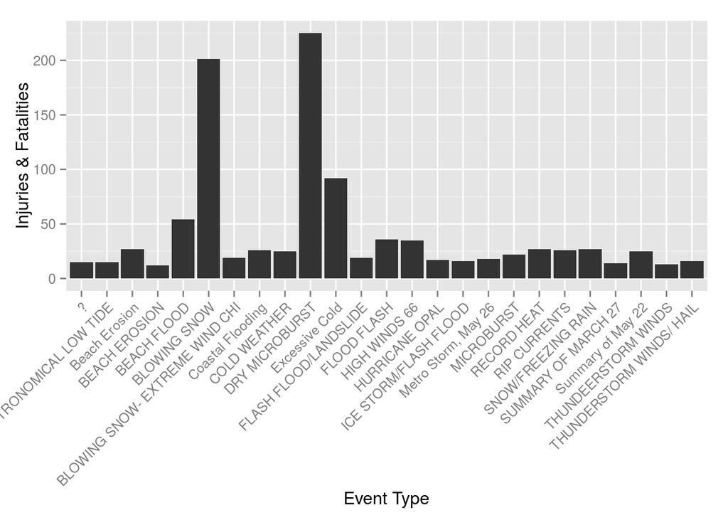

```r
require(ggplot2)
require(scales)
p1 <- ggplot(tpopharm, aes(EVTYPE, Population_Harm))
p1 <- p1 + geom_bar(stat="identity")
p1 <- p1 + theme(axis.text.x=element_text(angle=45,hjust=1,vjust=1))
p1 <- p1 + ylab("Injuries & Fatalities")
p1 <- p1 + xlab("Event Type")
p1
```

```r
tpopharm[1:2,]
```

```
##           EVTYPE Population_Harm
## 1 DRY MICROBURST             225
## 2   BLOWING SNOW             201
```

**2. Across the United States, which types of events have the greatest economic consequences?**

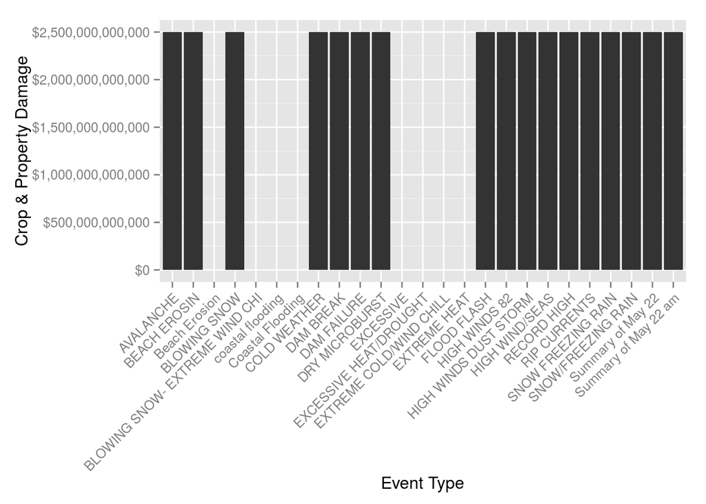

```r
p2 <- ggplot(tecon, aes(EVTYPE, EC))
p2 <- p2 + geom_bar(stat="identity")
p2 <- p2 + theme(axis.text.x=element_text(angle=45,hjust=1,vjust=1))
p2 <- p2 + scale_y_continuous(labels=dollar)
p2 <- p2 + ylab("Crop & Property Damage")
p2 <- p2 + xlab("Event Type")
p2
```

From the chart above, it is clear that the following events had the greatest economic consequences:

```r
require(scales)
tecondollars <- tecon
tecondollars$EC <- dollar(tecon$EC)
tecondollars[1:17, ]
```

```
##                   EVTYPE                 EC
## 1              AVALANCHE $2,500,000,000,000
## 2           BEACH EROSIN $2,500,000,000,000
## 3           BLOWING SNOW $2,500,000,000,000
## 4           COLD WEATHER $2,500,000,000,000
## 5              DAM BREAK $2,500,000,000,000
## 6            DAM FAILURE $2,500,000,000,000
## 7         DRY MICROBURST $2,500,000,000,000
## 8            FLOOD FLASH $2,500,000,000,000
## 9          HIGH WINDS 82 $2,500,000,000,000
## 10 HIGH WINDS DUST STORM $2,500,000,000,000
## 11        HIGH WIND/SEAS $2,500,000,000,000
## 12           RECORD HIGH $2,500,000,000,000
## 13          RIP CURRENTS $2,500,000,000,000
## 14    SNOW FREEZING RAIN $2,500,000,000,000
## 15    SNOW/FREEZING RAIN $2,500,000,000,000
## 16     Summary of May 22 $2,500,000,000,000
## 17  Summary of May 22 am $2,500,000,000,000
```

However, notice that **SNOW/FREEZING RAIN** is listed twice as both

- *SNOW/FREEZING RAIN*, and
- *SNOW FREEZING RAIN*.